# SIG04 DEG visualizations

Eric Y. Wang

2024-10-12

```r
source("functions/plotting_fxns.R")
source("functions/scRNA_seq_analysis_functions.R")
theme_set(theme_Publication())
```

## Import data

```r
degLane2 <- read_csv("analysis_outs/DEG_MAST_lane2.csv")
```

```r
# import seurat object and subset to singlets
data <- readRDS("C:/Users/Eric/Documents/datasets/EYW/SIG04_10x_240816/seurat_outs/SIG04_postqc_seurat.rds")
data <- subset(data, subset = oBC_classification == "singlet")
```

## Perturbation # Quantification

```r
pertNum <- data@meta.data %>%
  group_by(oBC_feature_call) %>%
  summarise(n = n())
pertNum
```

| oBC_feature_call | n |
| --- | --- |
| ADIPOQ | 676 |
| BMP10 | 583 |
| BMP4 | 394 |
| BMP7 | 417 |
| CCL12 | 433 |
| CCL19 | 698 |
| CCL2 | 213 |
| CCL21A | 398 |
| CCL25 | 697 |
| CCL3 | 623 |

[output cut: 73 more lines]

p129 has 5857 cells in the full dataset

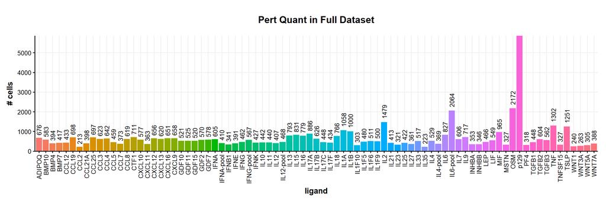

```r
pertNum %>%
  ggplot(aes(x=oBC_feature_call,y=n,fill=oBC_feature_call)) +
    geom_bar(stat = "identity") +
    geom_text(aes(label=n), position=position_dodge(width=0.9), angle=90, vjust=0.5, hjust=-0.25) +
    scale_y_continuous(expand = c(0, 0)) +
    xlab("ligand") +
    ylab("# cells") +
    ggtitle("Pert Quant in Full Dataset") +
    theme(legend.position = "none",
          axis.text.x = element_text(angle = 90, vjust = 0.5, hjust=1))
```

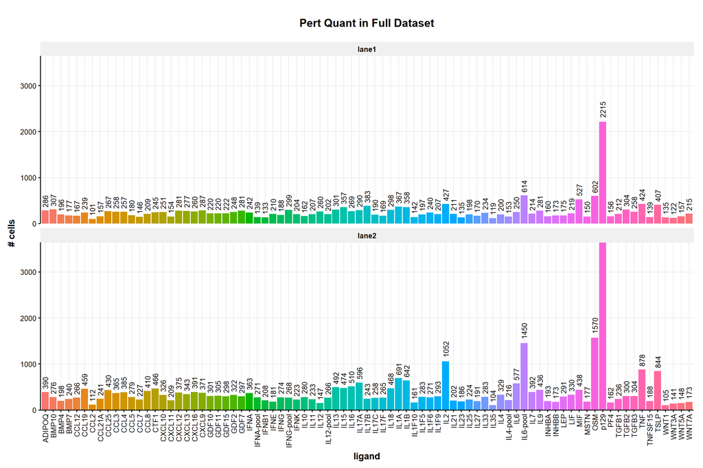

```r
data@meta.data %>%
  group_by(oBC_feature_call,gem_group) %>%
  summarise(n = n()) %>%
  ggplot(aes(x=oBC_feature_call,y=n,fill=oBC_feature_call)) +
    geom_bar(stat = "identity") +
    geom_text(aes(label=n), position=position_dodge(width=0.9), angle=90, vjust=0.5, hjust=-0.25) +
    scale_y_continuous(expand = c(0, 0)) +
    facet_wrap(~gem_group, ncol = 1) +
    xlab("ligand") +
    ylab("# cells") +
    ggtitle("Pert Quant in Full Dataset") +
    theme(legend.position = "none",
          axis.text.x = element_text(angle = 90, vjust = 0.5, hjust=1))
```

```r
assignments <- data@meta.data %>%
  group_by(oBC_feature_call,gem_group) %>%
  summarise(n = n())
write_csv(assignments, "analysis_outs/feature_assignment_counts.csv")
```

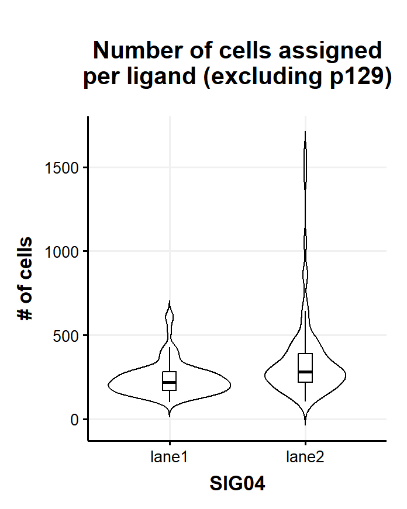

```r
assignments %>%
  filter(oBC_feature_call != "p129") %>%
  ggplot(aes(x=gem_group,y=n)) +
    geom_violin(trim = FALSE, color = "black") +
    geom_boxplot(width = 0.1, outlier.shape = NA, color = "black") +
    ylab("# of cells") +
    xlab("SIG04") +
    ggtitle("Number of cells assigned\nper ligand (excluding p129)")
```

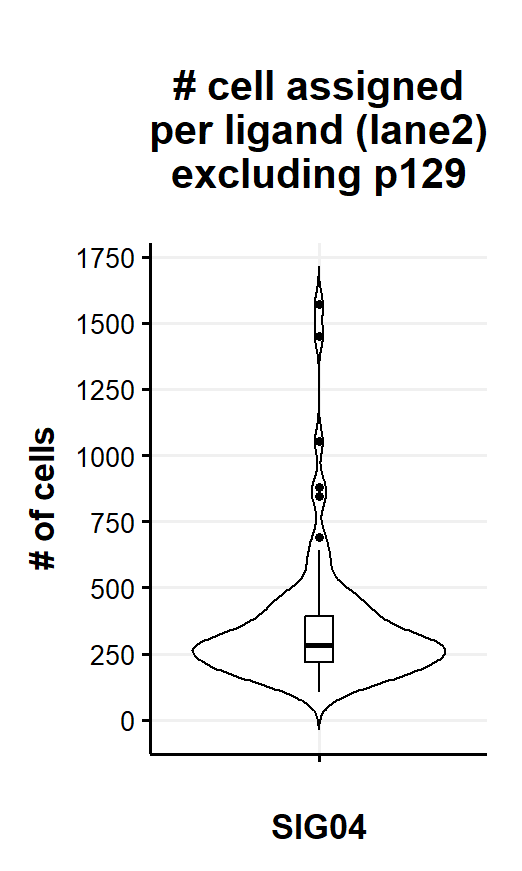

```r
assignments %>%
  filter(gem_group == "lane2" & oBC_feature_call != "p129") %>%
  ggplot(aes(x="",y=n)) +
    geom_violin(trim = FALSE, color = "black") +
    geom_boxplot(width = 0.1, color = "black") +
    scale_y_continuous(breaks = seq(0,1750,250)) +
    ylab("# of cells") +
    xlab("SIG04") +
    ggtitle("# cell assigned\nper ligand (lane2)\nexcluding p129")
```

## DEG Quantification

- quantify number of degs per ligand
- determine “uniqueness” of degs

### DEG Numbers

I’ll remove the pooled ligands for now since they’re not as relevant to our question.

```r
degFulloBCcov <- degFulloBCcov %>%
  filter(!grepl("-pool",comp_1))

degFullp139cov <- degFullp139cov %>%
  filter(!grepl("-pool",comp_1))

degGem <- degGem %>%
  filter(!grepl("-pool",comp_1))

degLane2 <- degLane2 %>%
  filter(!grepl("-pool",comp_1))
```

First, look at number of DEGs per ligand with different barcode adjustments.

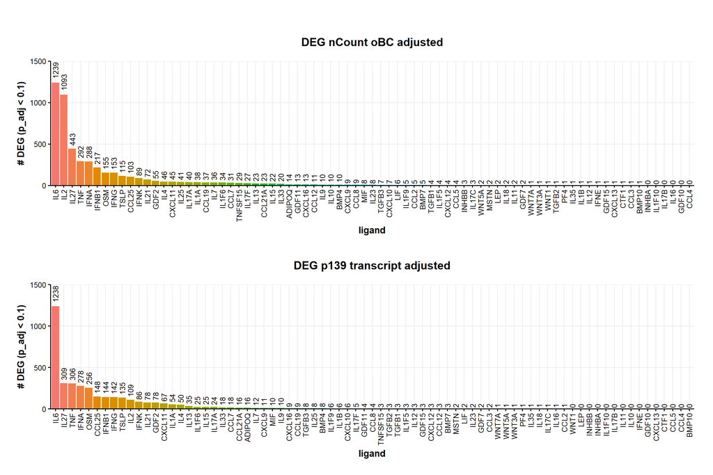

```r
p1 <- degFulloBCcov %>%
  mutate(sig = ifelse(p_val_adj < 0.1,T,F)) %>%
  group_by(comp_1) %>%
  summarise(n = sum(sig)) %>%
  mutate(comp_1 = fct_rev(fct_reorder(comp_1,n))) %>%
  ggplot(aes(x=comp_1,y=n,fill=comp_1)) +
    geom_bar(stat = "identity") +
    geom_text(aes(label=n), position=position_dodge(width=0.9),angle=90, vjust=0.5, hjust=-0.25) +
    scale_y_continuous(expand = c(0, 0), limits = c(0,1500)) +
    xlab("ligand") +
    ylab("# DEG (p_adj < 0.1)") +
    ggtitle("DEG nCount oBC adjusted") +
    theme(legend.position = "none",
          axis.text.x = element_text(angle = 90, vjust = 0.5, hjust=1))

p2 <- degFullp139cov %>%
  mutate(sig = ifelse(p_val_adj < 0.1,T,F)) %>%
  group_by(comp_1) %>%
  summarise(n = sum(sig)) %>%
  mutate(comp_1 = fct_rev(fct_reorder(comp_1,n))) %>%
  ggplot(aes(x=comp_1,y=n,fill=comp_1)) +
    geom_bar(stat = "identity") +
    geom_text(aes(label=n), position=position_dodge(width=0.9),angle=90, vjust=0.5, hjust=-0.25) +
    scale_y_continuous(expand = c(0, 0), limits = c(0,1500)) +
    xlab("ligand") +
    ylab("# DEG (p_adj < 0.1)") +
    ggtitle("DEG p139 transcript adjusted") +
    theme(legend.position = "none",
          axis.text.x = element_text(angle = 90, vjust = 0.5, hjust=1))

p1/p2
```

It’s interesting that there’s such a big difference between the two for IL2. In general it seems like adjusting using p139 transcript (which is much sparser than oBC) leads to decreased DEG identification. I’m not sure exactly is this is more or less “correct” as it could be an overcorrection. Perhaps IL2 is impacted in particular because there’s more virus uptake?

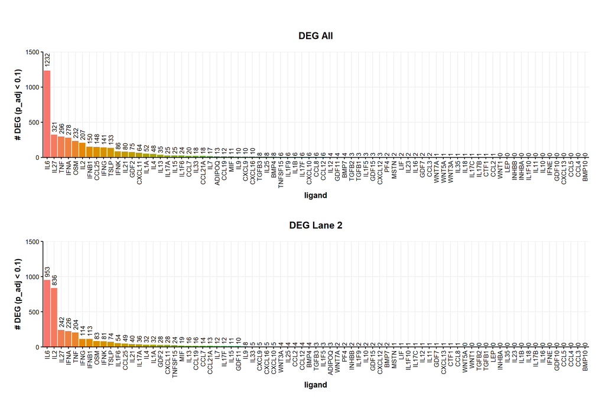

```r
p1 <- degGem %>%
  mutate(sig = ifelse(p_val_adj < 0.1,T,F)) %>%
  group_by(comp_1) %>%
  summarise(n = sum(sig)) %>%
  mutate(comp_1 = fct_rev(fct_reorder(comp_1,n))) %>%
  ggplot(aes(x=comp_1,y=n,fill=comp_1)) +
    geom_bar(stat = "identity") +
    geom_text(aes(label=n), position=position_dodge(width=0.9),angle=90, vjust=0.5, hjust=-0.25) +
    scale_y_continuous(expand = c(0, 0), limits = c(0,1500)) +
    xlab("ligand") +
    ylab("# DEG (p_adj < 0.1)") +
    ggtitle("DEG All") +
    theme(legend.position = "none",
          axis.text.x = element_text(angle = 90, vjust = 0.5, hjust=1))

p2 <- degLane2 %>%
  mutate(sig = ifelse(p_val_adj < 0.1,T,F)) %>%
  group_by(comp_1) %>%
  summarise(n = sum(sig)) %>%
  mutate(comp_1 = fct_rev(fct_reorder(comp_1,n))) %>%
  ggplot(aes(x=comp_1,y=n,fill=comp_1)) +
    geom_bar(stat = "identity") +
    geom_text(aes(label=n), position=position_dodge(width=0.9),angle=90, vjust=0.5, hjust=-0.25) +
    scale_y_continuous(expand = c(0, 0), limits = c(0,1500)) +
    xlab("ligand") +
    ylab("# DEG (p_adj < 0.1)") +
    ggtitle("DEG Lane 2") +
    theme(legend.position = "none",
          axis.text.x = element_text(angle = 90, vjust = 0.5, hjust=1))


p1/p2
```

### DEG uniqueness

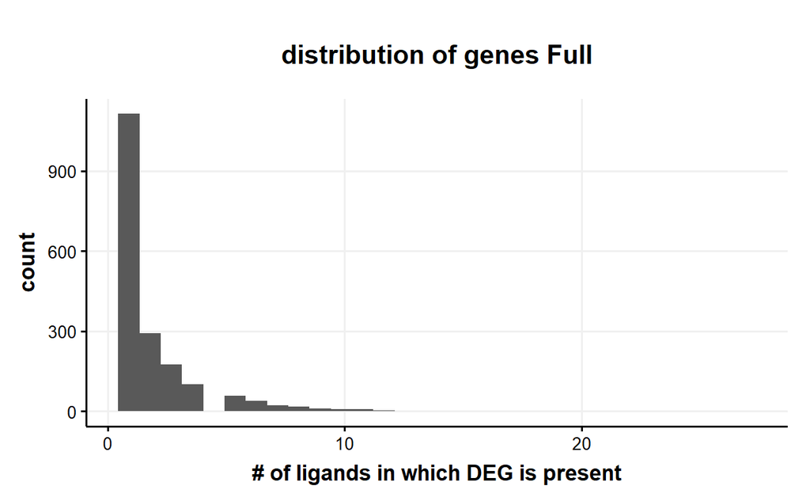

```r
degGem %>%
  filter(p_val_adj < 0.1) %>%
  group_by(genes) %>%
  summarise(n = n()) %>%
  ggplot(aes(x=n)) +
    geom_histogram() +
    xlab("# of ligands in which DEG is present") +
    ggtitle("distribution of genes Full")
```

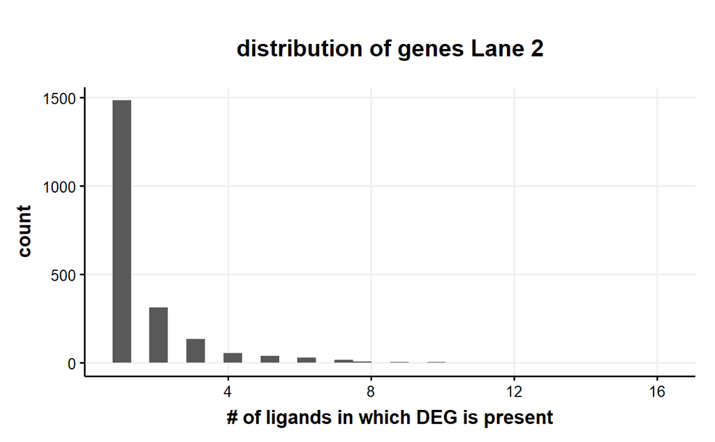

```r
degLane2 %>%
  filter(p_val_adj < 0.1) %>%
  group_by(genes) %>%
  summarise(n = n()) %>%
  ggplot(aes(x=n)) +
    geom_histogram() +
    xlab("# of ligands in which DEG is present") +
    ggtitle("distribution of genes Lane 2")
```

```r
# categorize genes by uniqueness
geneClass <- degGem %>%
  filter(p_val_adj < 0.1) %>%
  group_by(genes) %>%
  summarise(n_ligand = n()) %>%
  mutate(class = case_when(n_ligand == 1 ~ "unique",
                           n_ligand > 1 & n_ligand <=5 ~ "moderate (1-5)",
                           n_ligand > 5 & n_ligand <=10 ~ "high (5-10)",
                           n_ligand > 10 ~ "very high (10+)")) %>%
  mutate(class = factor(class, c("unique","moderate (1-5)","high (5-10)","very high (10+)")))

# categorize genes by uniqueness
geneClassLane2 <- degLane2 %>%
  filter(p_val_adj < 0.1) %>%
  group_by(genes) %>%
  summarise(n_ligand = n()) %>%
  mutate(class = case_when(n_ligand == 1 ~ "unique",
                           n_ligand > 1 & n_ligand <=4 ~ "moderate (1-4)",
                           n_ligand > 4 & n_ligand <=8 ~ "high (4-8)",
                           n_ligand > 8 ~ "very high (8+)")) %>%
  mutate(class = factor(class, c("unique","moderate (1-4)","high (4-8)","very high (8+)")))
```

```r
degGemSig <- degGem %>%
  filter(p_val_adj < 0.1) %>%
  left_join(geneClass, by="genes")
write_csv(degGemSig,"analysis_outs/DEG_MAST_gem_sig_geneClass.csv")

degGemSigGenes <- degGem %>%
  filter(p_val_adj < 0.1) %>%
  left_join(geneClass, by="genes") %>%
  select(genes, n_ligand, class) %>%
  unique()
write_csv(degGemSig,"analysis_outs/DEG_MAST_gem_sig_geneClass_genes_only.csv")

degLane2Sig <- degLane2 %>%
  filter(p_val_adj < 0.1) %>%
  left_join(geneClassLane2, by="genes")
write_csv(degLane2Sig,"analysis_outs/DEG_MAST_lane2_sig_geneClass.csv")

degLane2SigGenes <- degLane2 %>%
  filter(p_val_adj < 0.1) %>%
  left_join(geneClass, by="genes") %>%
  select(genes, n_ligand, class) %>%
  unique()
write_csv(degGemSig,"analysis_outs/DEG_MAST_lane2_sig_geneClass_genes_only.csv")
```

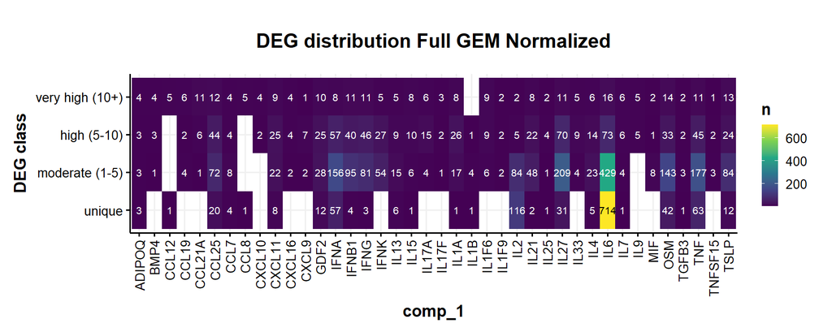

```r
# only pull out ligands with > 5 DEGs
ligands <- degGem %>%
  left_join(geneClass, by="genes") %>%
  mutate(sig = ifelse(p_val_adj < 0.1,T,F)) %>%
  group_by(comp_1) %>%
  summarise(n = sum(sig)) %>%
  filter(n > 5)

degGem %>%
  filter(comp_1 %in% ligands$comp_1) %>%
  filter(p_val_adj < 0.1) %>%
  left_join(geneClass, by="genes") %>%
  group_by(comp_1,class) %>%
  summarise(n = n()) %>%
  mutate(comp_1 = fct_reorder(comp_1,n)) %>%
  ggplot(aes(x=comp_1,y=class,fill=n)) +
    geom_tile() +
    geom_text(aes(label = n, color = ifelse(n > 500, "black", "white")),
            vjust = 0.5, hjust = 0.5, size = 3) +
    scale_fill_viridis_c() +
    scale_color_manual(values = c("black", "white"), guide = "none") +
    theme(axis.text.x = element_text(angle = 90, vjust = 0.5, hjust=1)) +
    ylab("ligand") +
    ylab("DEG class") +
    ggtitle("DEG distribution Full GEM Normalized")
```

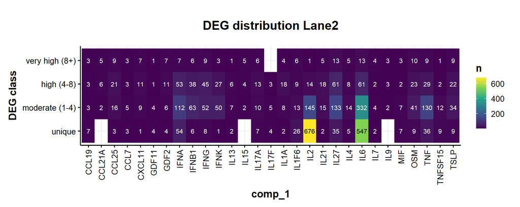

```r
# only pull out ligands with > 5 DEGs
ligands <- degLane2 %>%
  left_join(geneClass, by="genes") %>%
  mutate(sig = ifelse(p_val_adj < 0.1,T,F)) %>%
  group_by(comp_1) %>%
  summarise(n = sum(sig)) %>%
  filter(n > 5)

degLane2 %>%
  filter(comp_1 %in% ligands$comp_1) %>%
  filter(p_val_adj < 0.1) %>%
  left_join(geneClassLane2, by="genes") %>%
  group_by(comp_1,class) %>%
  summarise(n = n()) %>%
  mutate(comp_1 = fct_reorder(comp_1,n)) %>%
  ggplot(aes(x=comp_1,y=class,fill=n)) +
    geom_tile() +
    geom_text(aes(label = n, color = ifelse(n > 500, "black", "white")),
            vjust = 0.5, hjust = 0.5, size = 3) +
    scale_fill_viridis_c() +
    scale_color_manual(values = c("black", "white"), guide = "none") +
    theme(axis.text.x = element_text(angle = 90, vjust = 0.5, hjust=1)) +
    ylab("ligand") +
    ylab("DEG class") +
    ggtitle("DEG distribution Lane2")
```

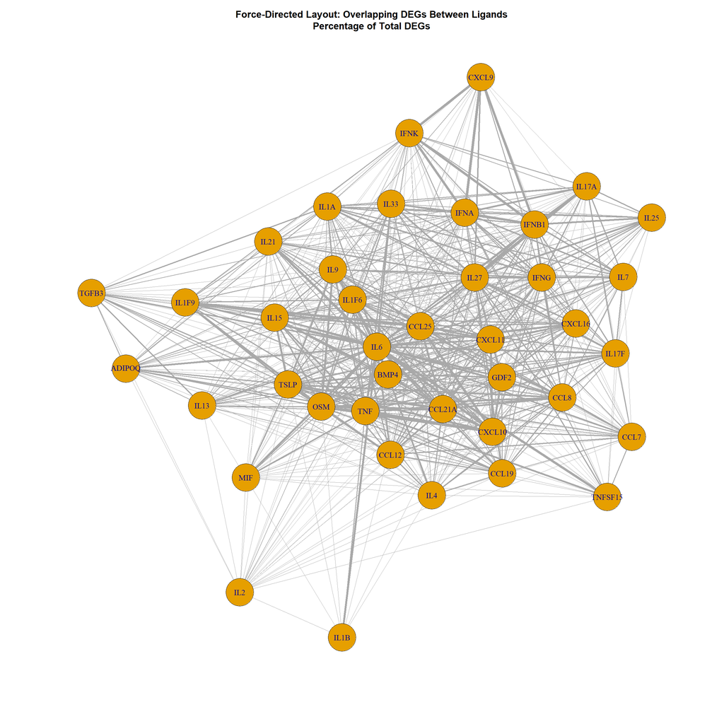

```r
library(igraph)

# only pull out ligands with > 5 DEGs
ligands <- degGem %>%
  left_join(geneClass, by="genes") %>%
  mutate(sig = ifelse(p_val_adj < 0.1,T,F)) %>%
  group_by(comp_1) %>%
  summarise(n = sum(sig)) %>%
  filter(n > 5)

# Assuming your tibble is called 'degs_tibble'
# Filter for significant DEGs
significant_degs <- degGem %>%
  filter(comp_1 %in% ligands$comp_1) %>%
  filter(p_val_adj < 0.1)


# Create a list of DEGs per ligand
ligand_gene_list <- significant_degs %>%
  group_by(comp_1) %>%
  summarize(genes = list(genes))

# Create a pairwise comparison of ligands based on the percentage of overlapping DEGs
edges <- combn(ligand_gene_list$comp_1, 2, function(pair) {
  ligand1 <- pair[1]
  ligand2 <- pair[2]

  # Get genes for each ligand
  genes1 <- ligand_gene_list %>% filter(comp_1 == ligand1) %>% pull(genes) %>% unlist()
  genes2 <- ligand_gene_list %>% filter(comp_1 == ligand2) %>% pull(genes) %>% unlist()

  # Calculate overlap and percentages
  overlap <- length(intersect(genes1, genes2))
  percentage_overlap <- overlap / min(length(genes1), length(genes2)) * 100  # Relative to smaller set

  if (overlap > 0) {
    return(data.frame(from = ligand1, to = ligand2, weight = percentage_overlap))
  } else {
    return(NULL)
  }
}, simplify = FALSE) %>%
  bind_rows()

# Create the igraph object
graph <- graph_from_data_frame(edges, directed = FALSE)

# Plot the graph using the force-directed layout
plot(graph, layout = layout.fruchterman.reingold, edge.width = E(graph)$weight*0.05,
     vertex.label = V(graph)$name, vertex.size = 10,
     main = "Force-Directed Layout: Overlapping DEGs Between Ligands\nPercentage of Total DEGs")
```

A few interesting things to note from this. CXCL9/10/11 have differnt signatures. CXCL9 is well connected to interferons while CXCL10/11 is not (even though the canonically both signal through CXCR3). This is well reflected in the DEGs.

## Volcano Plots Representative

```r
degLane2Plots <- degLane2
degLane2Plots$sig <- degLane2Plots$p_val_adj < 0.1
# I know this probably isn't kosher but I'm just going to replace
# the p_val_adj that are 0 with the smallest number
degLane2Plots <- degLane2Plots %>%
  mutate(p_val_adj = ifelse(p_val_adj == 0, 1e-306, p_val_adj))
```

```r
# helper function to make volcano plots
plot_volcano <- function(deg_tibble,feature){
  df <- deg_tibble %>%
  filter(comp_1 == feature)

  # Create the volcano plot
  ggplot(df, aes(x = avg_log2FC, y = -log10(p_val_adj), color = sig)) +
    geom_point(alpha = 0.7, size = 1) +  # Add points with transparency for better visualization
    scale_color_manual(values = c("black", "red")) +  # Color significant points in red
    geom_text_repel(data = subset(df, sig), aes(label = genes), color="black",
                    max.overlaps = 10, size = 4) +  # Label significant points with ggrepel
    labs(
      x = "Log2FC",
      y = "-log10(padj)",
      title = paste0(feature," DEGs")
    ) +
    theme(legend.position = "none", aspect.ratio=1)
}
```

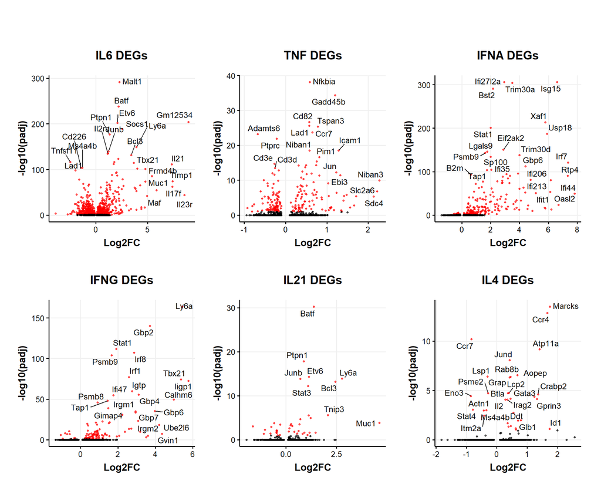

```r
p1 <- plot_volcano(degLane2Plots,"IL6")
p2 <- plot_volcano(degLane2Plots,"TNF")
p3 <- plot_volcano(degLane2Plots,"IFNA")
p4 <- plot_volcano(degLane2Plots,"IFNG")
p5 <- plot_volcano(degLane2Plots,"IL21")
p6 <- plot_volcano(degLane2Plots,"IL4")

p1+p2+p3+p4+p5+p6+plot_layout(ncol=3)
```

```r
ggsave("analysis_outs/volcano_plots_known_ligands.pdf")
```

Plot genes with few DEGs but biologically actionable information:

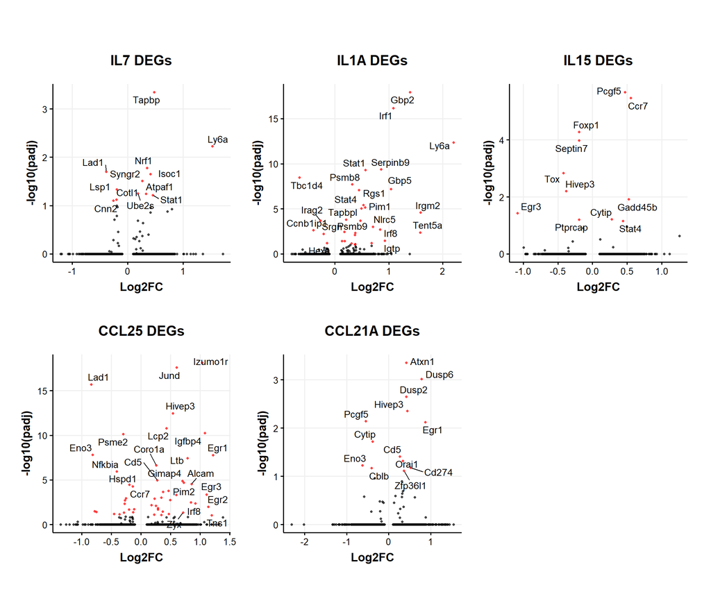

```r
p1 <- plot_volcano(degLane2Plots,"IL7")
p2 <- plot_volcano(degLane2Plots,"IL1A")
p3 <- plot_volcano(degLane2Plots,"IL15")
p4 <- plot_volcano(degLane2Plots,"CCL25")
p5 <- plot_volcano(degLane2Plots,"CCL21A")

p1+p2+p3+p4+p5+plot_layout(ncol=3)
```

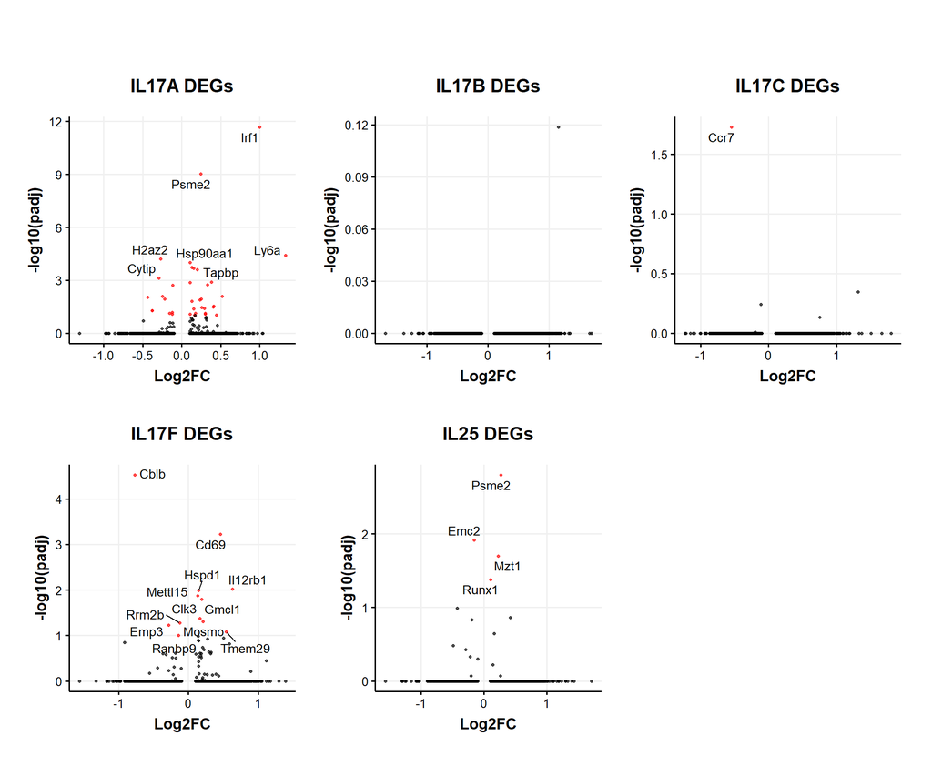

```r
p1 <- plot_volcano(degLane2Plots,"IL17A")
p2 <- plot_volcano(degLane2Plots,"IL17B")
p3 <- plot_volcano(degLane2Plots,"IL17C")
p4 <- plot_volcano(degLane2Plots,"IL17F")
p5 <- plot_volcano(degLane2Plots,"IL25")

p1+p2+p3+p4+p5+plot_layout(ncol=3)
```

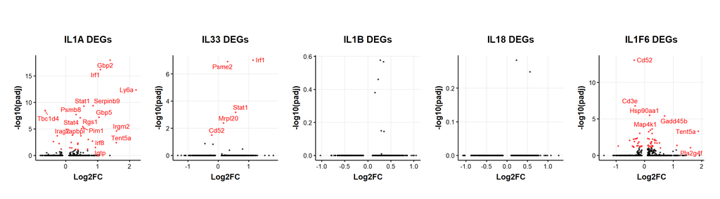

```r
p1 <- plot_volcano(degLane2Plots,"IL1A")
p2 <- plot_volcano(degLane2Plots,"IL33")
p3 <- plot_volcano(degLane2Plots,"IL1B")
p4 <- plot_volcano(degLane2Plots,"IL18")
p5 <- plot_volcano(degLane2Plots,"IL1F6")

p1+p2+p3+p4+p5+plot_layout(ncol=5)
```

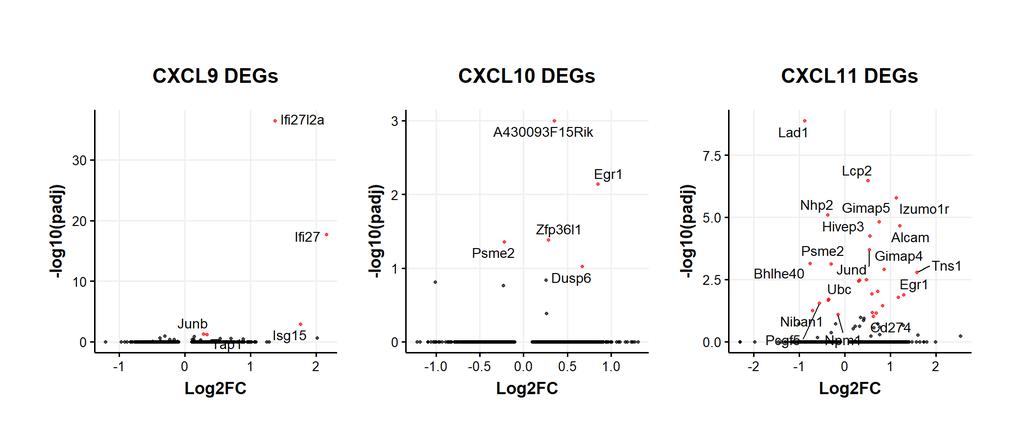

```r
p1 <- plot_volcano(degLane2Plots,"CXCL9")
p2 <- plot_volcano(degLane2Plots,"CXCL10")
p3 <- plot_volcano(degLane2Plots,"CXCL11")

p1+p2+p3+plot_layout(ncol=3)
```

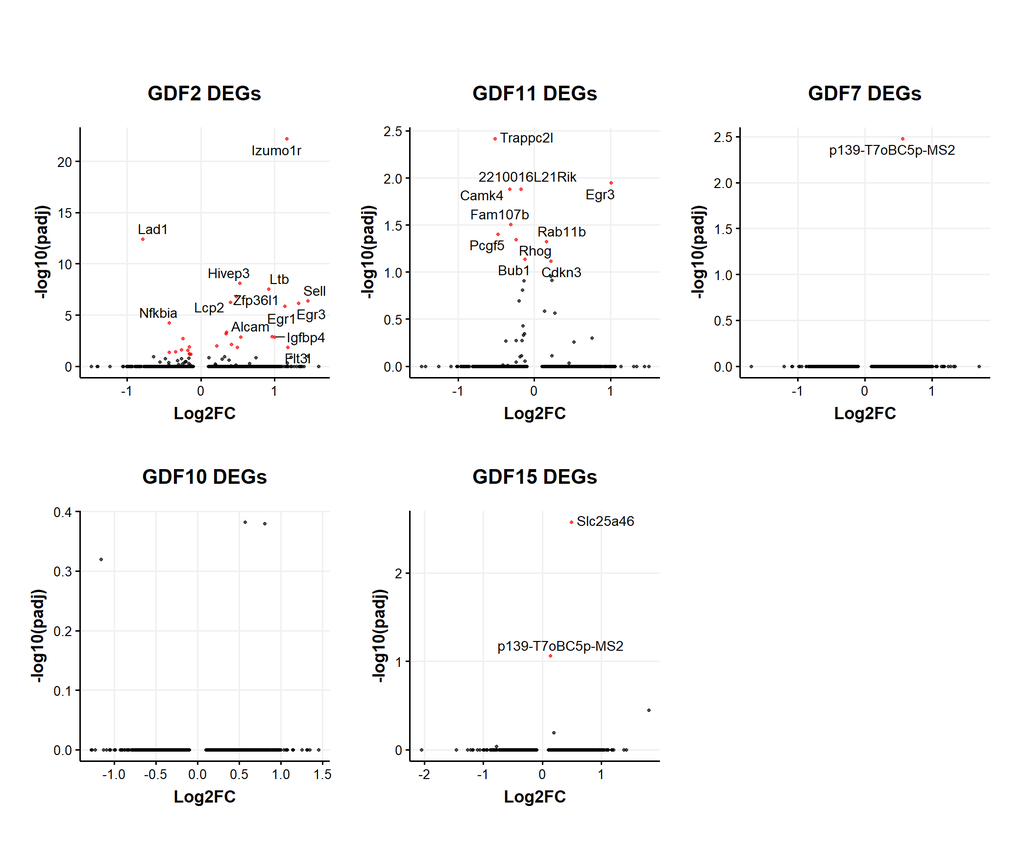

```r
p1 <- plot_volcano(degLane2Plots,"GDF2")
p2 <- plot_volcano(degLane2Plots,"GDF11")
p3 <- plot_volcano(degLane2Plots,"GDF7")
p4 <- plot_volcano(degLane2Plots,"GDF10")
p5 <- plot_volcano(degLane2Plots,"GDF15")

p1+p2+p3+p4+p5+plot_layout(ncol=3)
```

## Heatmaps Representative

```r
# get list of significant DEGs with shorter name lol
degSig <- degGem %>%
  filter(p_val_adj < 0.1)
```

```r
# subset data
dataSub <- subset(data, subset = oBC_feature_call %in% c("CXCL9","CXCL10","CXCL11","CXCL12","IFNA","p129") & gem_group == "lane2")
dataSub <- ScaleData(dataSub, features = rownames(dataSub))

# make heatmap with significant genes
genes <-  filter(degSig, comp_1 %in% c("CXCL9","CXCL10","CXCL11"))$genes %>% unique()
DoHeatmap(dataSub, features = genes, group.by = "oBC_feature_call")
```

[output not shown]

```r
library(ggpointdensity)
test <- tibble(Ifi27l2a_counts = GetAssayData(dataSub, assay = "RNA", layer = "counts")["p139-T7oBC5p-MS2",],
               Ifi27l2a_scale = GetAssayData(dataSub, assay = "RNA", layer = "scale.data")["p139-T7oBC5p-MS2",],
               oBC_nCount = dataSub$oBC_log1p_total_counts,
               gem_group = dataSub$gem_group,
               feature_call = dataSub$oBC_feature_call)

test %>%
  filter(gem_group == "lane2") %>%
  ggplot(aes(x = Ifi27l2a_scale, y = oBC_nCount)) +
    geom_pointdensity() +
    geom_density_2d() +
    scale_color_viridis_c()
```

[output not shown]

```r
VlnPlot(dataSub, c("Izumo1r","Ifi27l2a","Tap1","Stat1"), group.by = "oBC_feature_call", ncol = 2, pt.size = 0)
```

[output not shown]

```r
# subset data
dataSub <- subset(data, subset = oBC_feature_call %in% c("GDF2","GDF11","p129") & gem_group == "lane2")
dataSub <- ScaleData(dataSub, features = rownames(dataSub))

# make heatmap with significant genes
genes <-  filter(degSig, comp_1 %in% c("GDF2","GDF11","p129"))$genes %>% unique()
DoHeatmap(dataSub, features = genes, group.by = "oBC_feature_call")
```

[output not shown]